# Classical Mechanics Problem 2.43

## Problem Statement:

The basketball of problem 2.31 is thrown from a height of 2 m with initial velocity $v_0 = 15 {m \over s}$ and 45 degrees above the horizontal. **(a)** Use appropriate software to solve the quations of motion (2.61) for the ball's position $(x, y)$ and plot the trajectory. Show the corresponding trajectory in the absense of air resistence. **(b)** Use your plot to find how far the ball travels in the horizontal direction before it hits the floor. Compare with the corresponding range in a vacuum.

## Imports

```python
import math
import numpy as np
from scipy.integrate import odeint
import matplotlib.pyplot as plt
```

## System of Equations

The equations we use for the motion of the basketball (Equations (2.61)) are as follows: $$ \begin{align*} \begin{cases} m \dot{v}_x = -c \sqrt{v_x^2 + v_y^2}v_x \\ m \dot{v}_y = -mg - c \sqrt{v_x^2 + v_y^2}v_y \end{cases} \end{align*} $$ We need to solve for $(x, y)$. Our model function that contains the system of equations needs to contain $v_x$, $v_y$, $x$, and $y$. We will populate the array as follows: `[vx, vy, x, y]`. Using the `odeint` function, we need the equation system to input the state `[vx, vy, x, y]` and return `[dvxdt, dvydt, dxdt, dydt]`, the derivatives of position and velocity. The constant `c` can be calculated using the equation in the textbook $c = \gamma D^2$ where $\gamma = 0.25$ for a round projectile.

```python
def equation_system(state, t):
    m = 0.624
    g = 9.81
    c = 0.25 * (0.242**2)
    vx = state[0]
    vy = state[1]
    dxdt = vx
    dydt = vy
    dvxdt = (-c/m)*math.sqrt(vx**2 + vy**2)*vx
    dvydt = -g - (c/m)*math.sqrt(vx**2 + vy**2)*vy
    return [dvxdt, dvydt, dxdt, dydt]
```

## Acquiring Solution

```python
x0 = 0
y0 = 0
vx0 = 15/math.sqrt(2)
vy0 = vx0
state0 = [vx0, vy0, x0, y0]
```

The time interval is 2 seconds with 100 data points.

```python
t = np.linspace(0, 2, 100)
solution = odeint(equation_system, state0, t)
```

## Plotting the Solution

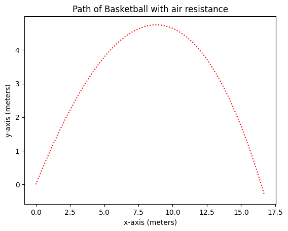

```python
x = solution[:, 2]
y = solution[:, 3]
plt.plot(x, y, 'r:')
plt.xlabel("x-axis (meters)")
plt.ylabel("y-axis (meters)")
plt.title("Path of Basketball with air resistance")
plt.show()
```

## Without Air Resistance

Without air resistance, we would have the system of equations:

$$ \begin{align*} \begin{cases} m\dot{v}_x = 0 \\ m\dot{v}_y = -mg \end{cases} \end{align*} $$

In this case, this is analytically solvable, so we can skip the first few steps of the last one and just plot the solution:

$$ \vec{r} = (x_0 + v_{x0}t)\hat{x} + (y_0 + v_{y0}t - \frac{1}2 gt^2)\hat{y} $$

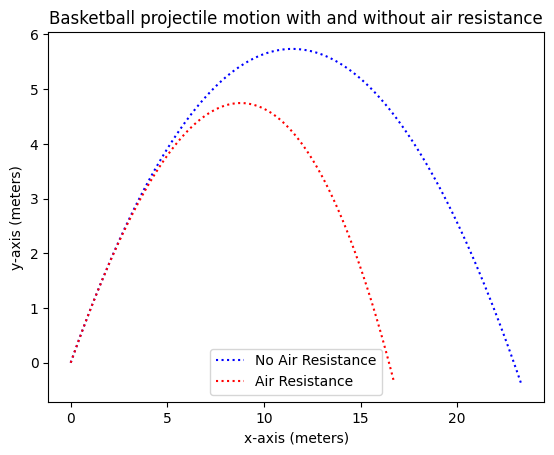

```python
t = np.linspace(0, 2.2, 100)
plt.plot(x0 + vx0*t, y0 + vy0*t - (1/2)*9.81*(t**2), 'b:', label="No Air Resistance")
plt.plot(x, y, 'r:', label="Air Resistance")
plt.xlabel("x-axis (meters)")
plt.ylabel("y-axis (meters)")
plt.title("Basketball projectile motion with and without air resistance")
plt.legend()
plt.show()
```

## Calculating Range of Projectile

In order to find the approximate range of the model, we find all of the time points in `solution` that are close to `y = 0`, and retrieve the x values at those time points. There are multiple points where rounding the y-value would give 0, so I take the average of the x values to get the approximate range. As seen below, the result is `16.44`.

```python
round(np.mean([
    x[2] for x in solution
        if round(x[3]) == 0  ## This is the y component
        and round(x[2]) != 0 ## This is the x component
]).item(), 2)
```

```
16.44
```

For the one without air resistance, to find the range, we can just use the equation, $R = v_0^2 sin(2\theta)/g$.

Since $\theta = $ `45`, $v_0 = $ `15`, and $g = $ `9.81`. Our equation simplifies to $R = 15^2 / 9.81$

```python
round((15**2)/9.81, 2)
```

```
22.94
```

As you can see - there is a 6 m discrepency which is not at all insignificant.

## Conclusion

There is a significant difference between the motion of the basketball with and without air resistance. Further, often when a basketball is used, the player gives the ball spin, which would influence the path even more. So, even with air resistance, we are not fully describing the motion of the ball. However, one step closer to accuracy is better than none.